# Risk Factor Analysis

## Outcome Variable

**Outcome Variable:** ever_co

## Predictor Variables

**Intervention Variable:** feducyrs

**Adjustment Set:**

- arm
- W_mage
- meducyrs
- hhwealth_quart
- W_mhtcm
- W_mwtkg
- W_mbmi
- W_gagebrth
- W_birthwt
- W_birthlen
- single
- delta_W_mage
- delta_meducyrs
- delta_hhwealth_quart
- delta_W_mhtcm
- delta_W_mwtkg
- delta_W_mbmi
- delta_W_gagebrth
- delta_W_birthwt
- delta_W_birthlen
- delta_single

## Stratifying Variables

The analysis was stratified on these variable(s):

- agecat
- studyid
- country

## Data Summary

| agecat | studyid | country | feducyrs | ever_co | n_cell | n |
| --- | --- | --- | --- | --- | --- | --- |
| 0-24 months | ki0047075b-MAL-ED | BANGLADESH | High | 0 | 50 | 147 |
| 0-24 months | ki0047075b-MAL-ED | BANGLADESH | High | 1 | 4 | 147 |
| 0-24 months | ki0047075b-MAL-ED | BANGLADESH | Low | 0 | 33 | 147 |
| 0-24 months | ki0047075b-MAL-ED | BANGLADESH | Low | 1 | 6 | 147 |
| 0-24 months | ki0047075b-MAL-ED | BANGLADESH | Medium | 0 | 45 | 147 |
| 0-24 months | ki0047075b-MAL-ED | BANGLADESH | Medium | 1 | 9 | 147 |
| 0-24 months | ki0047075b-MAL-ED | INDIA | High | 0 | 36 | 147 |
| 0-24 months | ki0047075b-MAL-ED | INDIA | High | 1 | 8 | 147 |
| 0-24 months | ki0047075b-MAL-ED | INDIA | Low | 0 | 46 | 147 |
| 0-24 months | ki0047075b-MAL-ED | INDIA | Low | 1 | 13 | 147 |
| 0-24 months | ki0047075b-MAL-ED | INDIA | Medium | 0 | 36 | 147 |
| 0-24 months | ki0047075b-MAL-ED | INDIA | Medium | 1 | 8 | 147 |
| 0-24 months | ki0047075b-MAL-ED | NEPAL | High | 0 | 39 | 98 |
| 0-24 months | ki0047075b-MAL-ED | NEPAL | High | 1 | 3 | 98 |
| 0-24 months | ki0047075b-MAL-ED | NEPAL | Low | 0 | 26 | 98 |
| 0-24 months | ki0047075b-MAL-ED | NEPAL | Low | 1 | 2 | 98 |
| 0-24 months | ki0047075b-MAL-ED | NEPAL | Medium | 0 | 21 | 98 |
| 0-24 months | ki0047075b-MAL-ED | NEPAL | Medium | 1 | 7 | 98 |
| 0-24 months | ki0047075b-MAL-ED | PERU | High | 0 | 116 | 250 |
| 0-24 months | ki0047075b-MAL-ED | PERU | High | 1 | 4 | 250 |
| 0-24 months | ki0047075b-MAL-ED | PERU | Low | 0 | 68 | 250 |
| 0-24 months | ki0047075b-MAL-ED | PERU | Low | 1 | 1 | 250 |
| 0-24 months | ki0047075b-MAL-ED | PERU | Medium | 0 | 58 | 250 |
| 0-24 months | ki0047075b-MAL-ED | PERU | Medium | 1 | 3 | 250 |
| 0-24 months | ki0047075b-MAL-ED | SOUTH AFRICA | High | 0 | 40 | 110 |
| 0-24 months | ki0047075b-MAL-ED | SOUTH AFRICA | High | 1 | 3 | 110 |
| 0-24 months | ki0047075b-MAL-ED | SOUTH AFRICA | Low | 0 | 34 | 110 |
| 0-24 months | ki0047075b-MAL-ED | SOUTH AFRICA | Low | 1 | 3 | 110 |
| 0-24 months | ki0047075b-MAL-ED | SOUTH AFRICA | Medium | 0 | 27 | 110 |
| 0-24 months | ki0047075b-MAL-ED | SOUTH AFRICA | Medium | 1 | 3 | 110 |

[output cut: 330 more lines]

The following strata were considered:

- agecat: 0-24 months, studyid: ki0047075b-MAL-ED, country: BANGLADESH
- agecat: 0-24 months, studyid: ki0047075b-MAL-ED, country: INDIA
- agecat: 0-24 months, studyid: ki0047075b-MAL-ED, country: NEPAL
- agecat: 0-24 months, studyid: ki0047075b-MAL-ED, country: PERU
- agecat: 0-24 months, studyid: ki0047075b-MAL-ED, country: SOUTH AFRICA
- agecat: 0-24 months, studyid: ki0047075b-MAL-ED, country: TANZANIA, UNITED REPUBLIC OF
- agecat: 0-24 months, studyid: ki1000304b-SAS-CompFeed, country: INDIA
- agecat: 0-24 months, studyid: ki1000304b-SAS-FoodSuppl, country: INDIA
- agecat: 0-24 months, studyid: ki1017093b-PROVIDE, country: BANGLADESH
- agecat: 0-24 months, studyid: ki1017093c-NIH-Crypto, country: BANGLADESH
- agecat: 0-24 months, studyid: ki1066203-TanzaniaChild2, country: TANZANIA, UNITED REPUBLIC OF
- agecat: 0-24 months, studyid: ki1113344-GMS-Nepal, country: NEPAL
- agecat: 0-24 months, studyid: ki1119695-PROBIT, country: BELARUS
- agecat: 0-24 months, studyid: ki1126311-ZVITAMBO, country: ZIMBABWE
- agecat: 0-24 months, studyid: ki1135781-COHORTS, country: GUATEMALA
- agecat: 0-24 months, studyid: ki1135781-COHORTS, country: INDIA
- agecat: 0-24 months, studyid: ki1135781-COHORTS, country: PHILIPPINES
- agecat: 0-24 months, studyid: ki1148112-LCNI-5, country: MALAWI
- agecat: 0-24 months, studyid: kiGH5241-JiVitA-3, country: BANGLADESH
- agecat: 0-24 months, studyid: kiGH5241-JiVitA-4, country: BANGLADESH
- agecat: 0-6 months, studyid: ki0047075b-MAL-ED, country: BANGLADESH
- agecat: 0-6 months, studyid: ki0047075b-MAL-ED, country: INDIA
- agecat: 0-6 months, studyid: ki0047075b-MAL-ED, country: NEPAL
- agecat: 0-6 months, studyid: ki0047075b-MAL-ED, country: PERU
- agecat: 0-6 months, studyid: ki0047075b-MAL-ED, country: SOUTH AFRICA
- agecat: 0-6 months, studyid: ki0047075b-MAL-ED, country: TANZANIA, UNITED REPUBLIC OF
- agecat: 0-6 months, studyid: ki1000304b-SAS-CompFeed, country: INDIA
- agecat: 0-6 months, studyid: ki1000304b-SAS-FoodSuppl, country: INDIA
- agecat: 0-6 months, studyid: ki1017093b-PROVIDE, country: BANGLADESH
- agecat: 0-6 months, studyid: ki1017093c-NIH-Crypto, country: BANGLADESH
- agecat: 0-6 months, studyid: ki1066203-TanzaniaChild2, country: TANZANIA, UNITED REPUBLIC OF
- agecat: 0-6 months, studyid: ki1113344-GMS-Nepal, country: NEPAL
- agecat: 0-6 months, studyid: ki1119695-PROBIT, country: BELARUS
- agecat: 0-6 months, studyid: ki1126311-ZVITAMBO, country: ZIMBABWE
- agecat: 0-6 months, studyid: ki1135781-COHORTS, country: GUATEMALA
- agecat: 0-6 months, studyid: ki1135781-COHORTS, country: INDIA
- agecat: 0-6 months, studyid: ki1135781-COHORTS, country: PHILIPPINES
- agecat: 0-6 months, studyid: ki1148112-LCNI-5, country: MALAWI
- agecat: 0-6 months, studyid: kiGH5241-JiVitA-3, country: BANGLADESH
- agecat: 0-6 months, studyid: kiGH5241-JiVitA-4, country: BANGLADESH
- agecat: 6-24 months, studyid: ki0047075b-MAL-ED, country: BANGLADESH
- agecat: 6-24 months, studyid: ki0047075b-MAL-ED, country: INDIA
- agecat: 6-24 months, studyid: ki0047075b-MAL-ED, country: NEPAL
- agecat: 6-24 months, studyid: ki0047075b-MAL-ED, country: PERU
- agecat: 6-24 months, studyid: ki0047075b-MAL-ED, country: SOUTH AFRICA
- agecat: 6-24 months, studyid: ki0047075b-MAL-ED, country: TANZANIA, UNITED REPUBLIC OF
- agecat: 6-24 months, studyid: ki1000304b-SAS-CompFeed, country: INDIA
- agecat: 6-24 months, studyid: ki1000304b-SAS-FoodSuppl, country: INDIA
- agecat: 6-24 months, studyid: ki1017093b-PROVIDE, country: BANGLADESH
- agecat: 6-24 months, studyid: ki1017093c-NIH-Crypto, country: BANGLADESH
- agecat: 6-24 months, studyid: ki1066203-TanzaniaChild2, country: TANZANIA, UNITED REPUBLIC OF
- agecat: 6-24 months, studyid: ki1113344-GMS-Nepal, country: NEPAL
- agecat: 6-24 months, studyid: ki1119695-PROBIT, country: BELARUS
- agecat: 6-24 months, studyid: ki1126311-ZVITAMBO, country: ZIMBABWE
- agecat: 6-24 months, studyid: ki1135781-COHORTS, country: GUATEMALA
- agecat: 6-24 months, studyid: ki1135781-COHORTS, country: INDIA
- agecat: 6-24 months, studyid: ki1135781-COHORTS, country: PHILIPPINES
- agecat: 6-24 months, studyid: ki1148112-LCNI-5, country: MALAWI
- agecat: 6-24 months, studyid: kiGH5241-JiVitA-3, country: BANGLADESH
- agecat: 6-24 months, studyid: kiGH5241-JiVitA-4, country: BANGLADESH

### Dropped Strata

Some strata were dropped due to rare outcomes:

- agecat: 0-24 months, studyid: ki0047075b-MAL-ED, country: BANGLADESH
- agecat: 0-24 months, studyid: ki0047075b-MAL-ED, country: NEPAL
- agecat: 0-24 months, studyid: ki0047075b-MAL-ED, country: PERU
- agecat: 0-24 months, studyid: ki0047075b-MAL-ED, country: SOUTH AFRICA
- agecat: 0-24 months, studyid: ki0047075b-MAL-ED, country: TANZANIA, UNITED REPUBLIC OF
- agecat: 0-24 months, studyid: ki1119695-PROBIT, country: BELARUS
- agecat: 0-6 months, studyid: ki0047075b-MAL-ED, country: BANGLADESH
- agecat: 0-6 months, studyid: ki0047075b-MAL-ED, country: INDIA
- agecat: 0-6 months, studyid: ki0047075b-MAL-ED, country: NEPAL
- agecat: 0-6 months, studyid: ki0047075b-MAL-ED, country: PERU
- agecat: 0-6 months, studyid: ki0047075b-MAL-ED, country: SOUTH AFRICA
- agecat: 0-6 months, studyid: ki0047075b-MAL-ED, country: TANZANIA, UNITED REPUBLIC OF
- agecat: 0-6 months, studyid: ki1017093c-NIH-Crypto, country: BANGLADESH
- agecat: 0-6 months, studyid: ki1066203-TanzaniaChild2, country: TANZANIA, UNITED REPUBLIC OF
- agecat: 0-6 months, studyid: ki1119695-PROBIT, country: BELARUS
- agecat: 0-6 months, studyid: ki1135781-COHORTS, country: GUATEMALA
- agecat: 0-6 months, studyid: ki1148112-LCNI-5, country: MALAWI
- agecat: 6-24 months, studyid: ki0047075b-MAL-ED, country: BANGLADESH
- agecat: 6-24 months, studyid: ki0047075b-MAL-ED, country: NEPAL
- agecat: 6-24 months, studyid: ki0047075b-MAL-ED, country: PERU
- agecat: 6-24 months, studyid: ki0047075b-MAL-ED, country: SOUTH AFRICA
- agecat: 6-24 months, studyid: ki0047075b-MAL-ED, country: TANZANIA, UNITED REPUBLIC OF
- agecat: 6-24 months, studyid: ki1119695-PROBIT, country: BELARUS

## Methods Detail

We’re interested in the causal parameters $E[Y_a]$ for all values of $a \in \mathcal{A}$. These parameters represent the mean outcome if, possibly contrary to fact, we intervened to set all units to have $A=a$. Under the randomization and positivity assumptions, these are identified by the statistical parameters $\psi_a=E_W[E_{Y|A,W}(Y|A=a,W)]$. In addition, we’re interested in the mean of $Y$, $E[Y]$ under no intervention (the observed mean). We will estimate these parameters by using SuperLearner to fit the relevant likelihood factors – $E_{Y|A,W}(Y|A=a,W)$ and $p(A=a|W)$, and then updating our likelihood fit using a joint TMLE.

For unadjusted analyses ($W=\{\}$), initial likelihoods were estimated using Lrnr_glm to estimate the simple $E(Y|A)$ and Lrnr_mean to estimate $p(A)$. For adjusted analyses, a small library containing Lrnr_glmnet, Lrnr_xgboost, and Lrnr_mean was used.

Having estimated these parameters, we will then use the delta method to estimate relative risks and attributable risks relative to a prespecified baseline level of $A$.

# Results Detail

## Results Plots

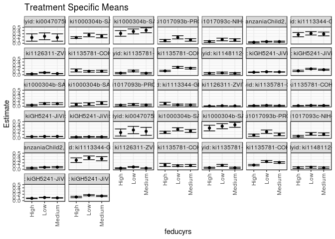

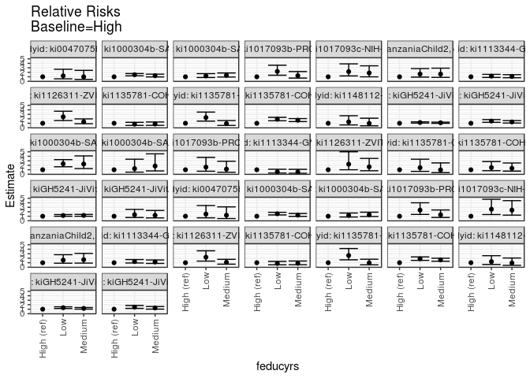

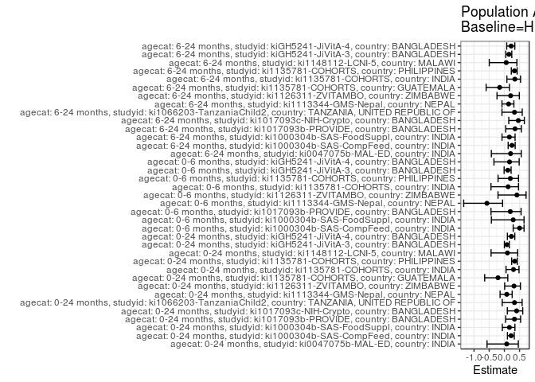

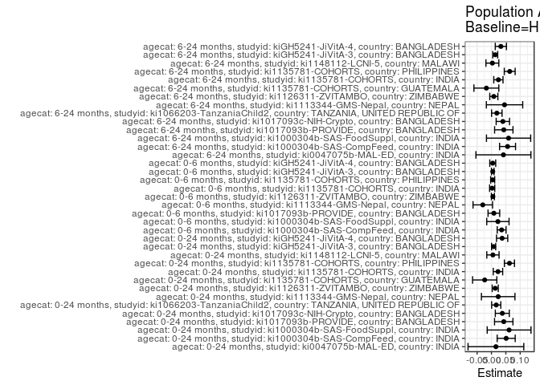

## Results Table

### Parameter: TSM

| agecat | studyid | country | intervention_level | baseline_level | estimate | ci_lower | ci_upper |
| --- | --- | --- | --- | --- | --- | --- | --- |
| 0-24 months | ki0047075b-MAL-ED | INDIA | High | NA | 0.1818182 | 0.0674652 | 0.2961712 |
| 0-24 months | ki0047075b-MAL-ED | INDIA | Low | NA | 0.2203390 | 0.1142176 | 0.3264604 |
| 0-24 months | ki0047075b-MAL-ED | INDIA | Medium | NA | 0.1818182 | 0.0674652 | 0.2961712 |
| 0-24 months | ki1000304b-SAS-CompFeed | INDIA | High | NA | 0.1799365 | 0.1513686 | 0.2085043 |
| 0-24 months | ki1000304b-SAS-CompFeed | INDIA | Low | NA | 0.2612924 | 0.2042131 | 0.3183717 |
| 0-24 months | ki1000304b-SAS-CompFeed | INDIA | Medium | NA | 0.2231838 | 0.1727193 | 0.2736484 |
| 0-24 months | ki1000304b-SAS-FoodSuppl | INDIA | High | NA | 0.3094637 | 0.2219405 | 0.3969868 |
| 0-24 months | ki1000304b-SAS-FoodSuppl | INDIA | Low | NA | 0.3707408 | 0.2927998 | 0.4486818 |
| 0-24 months | ki1000304b-SAS-FoodSuppl | INDIA | Medium | NA | 0.4081159 | 0.3317291 | 0.4845026 |
| 0-24 months | ki1017093b-PROVIDE | BANGLADESH | High | NA | 0.0858225 | 0.0505711 | 0.1210738 |
| 0-24 months | ki1017093b-PROVIDE | BANGLADESH | Low | NA | 0.1884161 | 0.1381030 | 0.2387292 |
| 0-24 months | ki1017093b-PROVIDE | BANGLADESH | Medium | NA | 0.1067871 | 0.0669084 | 0.1466658 |
| 0-24 months | ki1017093c-NIH-Crypto | BANGLADESH | High | NA | 0.0559557 | 0.0293552 | 0.0825563 |
| 0-24 months | ki1017093c-NIH-Crypto | BANGLADESH | Low | NA | 0.1204742 | 0.0787750 | 0.1621734 |
| 0-24 months | ki1017093c-NIH-Crypto | BANGLADESH | Medium | NA | 0.1034840 | 0.0620374 | 0.1449307 |
| 0-24 months | ki1066203-TanzaniaChild2 | TANZANIA, UNITED REPUBLIC OF | High | NA | 0.0330041 | 0.0162329 | 0.0497753 |
| 0-24 months | ki1066203-TanzaniaChild2 | TANZANIA, UNITED REPUBLIC OF | Low | NA | 0.0533447 | 0.0409459 | 0.0657435 |
| 0-24 months | ki1066203-TanzaniaChild2 | TANZANIA, UNITED REPUBLIC OF | Medium | NA | 0.0527139 | 0.0355534 | 0.0698744 |
| 0-24 months | ki1113344-GMS-Nepal | NEPAL | High | NA | 0.2719382 | 0.2050299 | 0.3388466 |
| 0-24 months | ki1113344-GMS-Nepal | NEPAL | Low | NA | 0.3119170 | 0.2590164 | 0.3648177 |
| 0-24 months | ki1113344-GMS-Nepal | NEPAL | Medium | NA | 0.2927501 | 0.2340726 | 0.3514276 |
| 0-24 months | ki1126311-ZVITAMBO | ZIMBABWE | High | NA | 0.0281457 | 0.0174394 | 0.0388521 |
| 0-24 months | ki1126311-ZVITAMBO | ZIMBABWE | Low | NA | 0.0684145 | 0.0568689 | 0.0799601 |
| 0-24 months | ki1126311-ZVITAMBO | ZIMBABWE | Medium | NA | 0.0374611 | 0.0336328 | 0.0412895 |
| 0-24 months | ki1135781-COHORTS | GUATEMALA | High | NA | 0.1362305 | 0.0896134 | 0.1828476 |
| 0-24 months | ki1135781-COHORTS | GUATEMALA | Low | NA | 0.1093960 | 0.0833471 | 0.1354450 |
| 0-24 months | ki1135781-COHORTS | GUATEMALA | Medium | NA | 0.1133653 | 0.0825483 | 0.1441823 |
| 0-24 months | ki1135781-COHORTS | INDIA | High | NA | 0.0527083 | 0.0341742 | 0.0712425 |
| 0-24 months | ki1135781-COHORTS | INDIA | Low | NA | 0.1197316 | 0.0901591 | 0.1493042 |
| 0-24 months | ki1135781-COHORTS | INDIA | Medium | NA | 0.0482968 | 0.0271528 | 0.0694409 |

[output cut: 81 more lines]

### Parameter: E(Y)

| agecat | studyid | country | intervention_level | baseline_level | estimate | ci_lower | ci_upper |
| --- | --- | --- | --- | --- | --- | --- | --- |
| 0-24 months | ki0047075b-MAL-ED | INDIA | NA | NA | 0.1972789 | 0.1327292 | 0.2618286 |
| 0-24 months | ki1000304b-SAS-CompFeed | INDIA | NA | NA | 0.2311258 | 0.1911027 | 0.2711489 |
| 0-24 months | ki1000304b-SAS-FoodSuppl | INDIA | NA | NA | 0.3708134 | 0.3244530 | 0.4171738 |
| 0-24 months | ki1017093b-PROVIDE | BANGLADESH | NA | NA | 0.1285714 | 0.1037574 | 0.1533855 |
| 0-24 months | ki1017093c-NIH-Crypto | BANGLADESH | NA | NA | 0.0936675 | 0.0729118 | 0.1144233 |
| 0-24 months | ki1066203-TanzaniaChild2 | TANZANIA, UNITED REPUBLIC OF | NA | NA | 0.0495174 | 0.0408052 | 0.0582296 |
| 0-24 months | ki1113344-GMS-Nepal | NEPAL | NA | NA | 0.2953216 | 0.2611095 | 0.3295338 |
| 0-24 months | ki1126311-ZVITAMBO | ZIMBABWE | NA | NA | 0.0412120 | 0.0378667 | 0.0445574 |
| 0-24 months | ki1135781-COHORTS | GUATEMALA | NA | NA | 0.1126418 | 0.0949950 | 0.1302886 |
| 0-24 months | ki1135781-COHORTS | INDIA | NA | NA | 0.0753283 | 0.0617252 | 0.0889313 |
| 0-24 months | ki1135781-COHORTS | PHILIPPINES | NA | NA | 0.1847978 | 0.1705903 | 0.1990052 |
| 0-24 months | ki1148112-LCNI-5 | MALAWI | NA | NA | 0.0504305 | 0.0353790 | 0.0654820 |
| 0-24 months | kiGH5241-JiVitA-3 | BANGLADESH | NA | NA | 0.0882455 | 0.0842753 | 0.0922157 |
| 0-24 months | kiGH5241-JiVitA-4 | BANGLADESH | NA | NA | 0.1607278 | 0.1492347 | 0.1722209 |
| 0-6 months | ki1000304b-SAS-CompFeed | INDIA | NA | NA | 0.0706196 | 0.0480792 | 0.0931600 |
| 0-6 months | ki1000304b-SAS-FoodSuppl | INDIA | NA | NA | 0.0769231 | 0.0512858 | 0.1025603 |
| 0-6 months | ki1017093b-PROVIDE | BANGLADESH | NA | NA | 0.0428571 | 0.0278427 | 0.0578716 |
| 0-6 months | ki1113344-GMS-Nepal | NEPAL | NA | NA | 0.0526316 | 0.0358852 | 0.0693779 |
| 0-6 months | ki1126311-ZVITAMBO | ZIMBABWE | NA | NA | 0.0121001 | 0.0102537 | 0.0139464 |
| 0-6 months | ki1135781-COHORTS | INDIA | NA | NA | 0.0204658 | 0.0130911 | 0.0278404 |
| 0-6 months | ki1135781-COHORTS | PHILIPPINES | NA | NA | 0.0212766 | 0.0159935 | 0.0265597 |
| 0-6 months | kiGH5241-JiVitA-3 | BANGLADESH | NA | NA | 0.0393561 | 0.0368043 | 0.0419078 |
| 0-6 months | kiGH5241-JiVitA-4 | BANGLADESH | NA | NA | 0.0260870 | 0.0207411 | 0.0314328 |
| 6-24 months | ki0047075b-MAL-ED | INDIA | NA | NA | 0.2043796 | 0.1366076 | 0.2721516 |
| 6-24 months | ki1000304b-SAS-CompFeed | INDIA | NA | NA | 0.2251082 | 0.1905625 | 0.2596539 |
| 6-24 months | ki1000304b-SAS-FoodSuppl | INDIA | NA | NA | 0.3615960 | 0.3145115 | 0.4086805 |
| 6-24 months | ki1017093b-PROVIDE | BANGLADESH | NA | NA | 0.1221498 | 0.0962275 | 0.1480722 |
| 6-24 months | ki1017093c-NIH-Crypto | BANGLADESH | NA | NA | 0.0863014 | 0.0659171 | 0.1066856 |
| 6-24 months | ki1066203-TanzaniaChild2 | TANZANIA, UNITED REPUBLIC OF | NA | NA | 0.0557769 | 0.0457368 | 0.0658170 |
| 6-24 months | ki1113344-GMS-Nepal | NEPAL | NA | NA | 0.3259762 | 0.2880893 | 0.3638632 |
| 6-24 months | ki1126311-ZVITAMBO | ZIMBABWE | NA | NA | 0.0395163 | 0.0357901 | 0.0432425 |
| 6-24 months | ki1135781-COHORTS | GUATEMALA | NA | NA | 0.1147687 | 0.0961264 | 0.1334109 |
| 6-24 months | ki1135781-COHORTS | INDIA | NA | NA | 0.0697509 | 0.0564268 | 0.0830750 |
| 6-24 months | ki1135781-COHORTS | PHILIPPINES | NA | NA | 0.1917860 | 0.1768046 | 0.2067673 |
| 6-24 months | ki1148112-LCNI-5 | MALAWI | NA | NA | 0.0511222 | 0.0358697 | 0.0663747 |
| 6-24 months | kiGH5241-JiVitA-3 | BANGLADESH | NA | NA | 0.0864979 | 0.0817318 | 0.0912639 |
| 6-24 months | kiGH5241-JiVitA-4 | BANGLADESH | NA | NA | 0.1471927 | 0.1364565 | 0.1579289 |

### Parameter: RR

| agecat | studyid | country | intervention_level | baseline_level | estimate | ci_lower | ci_upper |
| --- | --- | --- | --- | --- | --- | --- | --- |
| 0-24 months | ki0047075b-MAL-ED | INDIA | High | High | 1.0000000 | 1.0000000 | 1.000000 |
| 0-24 months | ki0047075b-MAL-ED | INDIA | Low | High | 1.2118644 | 0.5488063 | 2.676017 |
| 0-24 months | ki0047075b-MAL-ED | INDIA | Medium | High | 1.0000000 | 0.4108786 | 2.433809 |
| 0-24 months | ki1000304b-SAS-CompFeed | INDIA | High | High | 1.0000000 | 1.0000000 | 1.000000 |
| 0-24 months | ki1000304b-SAS-CompFeed | INDIA | Low | High | 1.4521372 | 1.2220103 | 1.725601 |
| 0-24 months | ki1000304b-SAS-CompFeed | INDIA | Medium | High | 1.2403480 | 0.9692515 | 1.587269 |
| 0-24 months | ki1000304b-SAS-FoodSuppl | INDIA | High | High | 1.0000000 | 1.0000000 | 1.000000 |
| 0-24 months | ki1000304b-SAS-FoodSuppl | INDIA | Low | High | 1.1980108 | 0.8424387 | 1.703661 |
| 0-24 months | ki1000304b-SAS-FoodSuppl | INDIA | Medium | High | 1.3187844 | 0.9394962 | 1.851197 |
| 0-24 months | ki1017093b-PROVIDE | BANGLADESH | High | High | 1.0000000 | 1.0000000 | 1.000000 |
| 0-24 months | ki1017093b-PROVIDE | BANGLADESH | Low | High | 2.1954174 | 1.3457154 | 3.581632 |
| 0-24 months | ki1017093b-PROVIDE | BANGLADESH | Medium | High | 1.2442796 | 0.7150850 | 2.165102 |
| 0-24 months | ki1017093c-NIH-Crypto | BANGLADESH | High | High | 1.0000000 | 1.0000000 | 1.000000 |
| 0-24 months | ki1017093c-NIH-Crypto | BANGLADESH | Low | High | 2.1530267 | 1.1956514 | 3.876986 |
| 0-24 months | ki1017093c-NIH-Crypto | BANGLADESH | Medium | High | 1.8493911 | 0.9930330 | 3.444244 |
| 0-24 months | ki1066203-TanzaniaChild2 | TANZANIA, UNITED REPUBLIC OF | High | High | 1.0000000 | 1.0000000 | 1.000000 |
| 0-24 months | ki1066203-TanzaniaChild2 | TANZANIA, UNITED REPUBLIC OF | Low | High | 1.6163077 | 0.9243755 | 2.826179 |
| 0-24 months | ki1066203-TanzaniaChild2 | TANZANIA, UNITED REPUBLIC OF | Medium | High | 1.5971940 | 0.8733832 | 2.920858 |
| 0-24 months | ki1113344-GMS-Nepal | NEPAL | High | High | 1.0000000 | 1.0000000 | 1.000000 |
| 0-24 months | ki1113344-GMS-Nepal | NEPAL | Low | High | 1.1470143 | 0.8548750 | 1.538987 |
| 0-24 months | ki1113344-GMS-Nepal | NEPAL | Medium | High | 1.0765317 | 0.7878932 | 1.470911 |
| 0-24 months | ki1126311-ZVITAMBO | ZIMBABWE | High | High | 1.0000000 | 1.0000000 | 1.000000 |
| 0-24 months | ki1126311-ZVITAMBO | ZIMBABWE | Low | High | 2.4307227 | 1.6032514 | 3.685269 |
| 0-24 months | ki1126311-ZVITAMBO | ZIMBABWE | Medium | High | 1.3309704 | 0.8976728 | 1.973416 |
| 0-24 months | ki1135781-COHORTS | GUATEMALA | High | High | 1.0000000 | 1.0000000 | 1.000000 |
| 0-24 months | ki1135781-COHORTS | GUATEMALA | Low | High | 0.8030215 | 0.5293194 | 1.218250 |
| 0-24 months | ki1135781-COHORTS | GUATEMALA | Medium | High | 0.8321579 | 0.5376986 | 1.287872 |
| 0-24 months | ki1135781-COHORTS | INDIA | High | High | 1.0000000 | 1.0000000 | 1.000000 |
| 0-24 months | ki1135781-COHORTS | INDIA | Low | High | 2.2715888 | 1.4780194 | 3.491237 |
| 0-24 months | ki1135781-COHORTS | INDIA | Medium | High | 0.9163031 | 0.5227184 | 1.606240 |

[output cut: 81 more lines]

### Parameter: PAR

| agecat | studyid | country | intervention_level | baseline_level | estimate | ci_lower | ci_upper |
| --- | --- | --- | --- | --- | --- | --- | --- |
| 0-24 months | ki0047075b-MAL-ED | INDIA | High | NA | 0.0154607 | -0.0815707 | 0.1124922 |
| 0-24 months | ki1000304b-SAS-CompFeed | INDIA | High | NA | 0.0511894 | 0.0197689 | 0.0826098 |
| 0-24 months | ki1000304b-SAS-FoodSuppl | INDIA | High | NA | 0.0613497 | -0.0148618 | 0.1375613 |
| 0-24 months | ki1017093b-PROVIDE | BANGLADESH | High | NA | 0.0427490 | 0.0106890 | 0.0748090 |
| 0-24 months | ki1017093c-NIH-Crypto | BANGLADESH | High | NA | 0.0377118 | 0.0133990 | 0.0620246 |
| 0-24 months | ki1066203-TanzaniaChild2 | TANZANIA, UNITED REPUBLIC OF | High | NA | 0.0165134 | 0.0006294 | 0.0323973 |
| 0-24 months | ki1113344-GMS-Nepal | NEPAL | High | NA | 0.0233834 | -0.0349655 | 0.0817323 |
| 0-24 months | ki1126311-ZVITAMBO | ZIMBABWE | High | NA | 0.0130663 | 0.0025655 | 0.0235671 |
| 0-24 months | ki1135781-COHORTS | GUATEMALA | High | NA | -0.0235887 | -0.0658178 | 0.0186404 |
| 0-24 months | ki1135781-COHORTS | INDIA | High | NA | 0.0226199 | 0.0062312 | 0.0390086 |
| 0-24 months | ki1135781-COHORTS | PHILIPPINES | High | NA | 0.0625708 | 0.0449442 | 0.0801973 |
| 0-24 months | ki1148112-LCNI-5 | MALAWI | High | NA | 0.0051112 | -0.0162527 | 0.0264750 |
| 0-24 months | kiGH5241-JiVitA-3 | BANGLADESH | High | NA | 0.0075627 | 0.0003785 | 0.0147468 |
| 0-24 months | kiGH5241-JiVitA-4 | BANGLADESH | High | NA | 0.0371377 | 0.0176334 | 0.0566419 |
| 0-6 months | ki1000304b-SAS-CompFeed | INDIA | High | NA | 0.0353501 | 0.0199100 | 0.0507902 |
| 0-6 months | ki1000304b-SAS-FoodSuppl | INDIA | High | NA | 0.0223776 | -0.0164533 | 0.0612085 |
| 0-6 months | ki1017093b-PROVIDE | BANGLADESH | High | NA | 0.0083744 | -0.0119125 | 0.0286613 |
| 0-6 months | ki1113344-GMS-Nepal | NEPAL | High | NA | -0.0302087 | -0.0641987 | 0.0037814 |
| 0-6 months | ki1126311-ZVITAMBO | ZIMBABWE | High | NA | 0.0049935 | -0.0001935 | 0.0101805 |
| 0-6 months | ki1135781-COHORTS | INDIA | High | NA | 0.0025125 | -0.0064544 | 0.0114793 |
| 0-6 months | ki1135781-COHORTS | PHILIPPINES | High | NA | 0.0041871 | -0.0028552 | 0.0112293 |
| 0-6 months | kiGH5241-JiVitA-3 | BANGLADESH | High | NA | 0.0044912 | -0.0000055 | 0.0089880 |
| 0-6 months | kiGH5241-JiVitA-4 | BANGLADESH | High | NA | 0.0044397 | -0.0058811 | 0.0147606 |
| 6-24 months | ki0047075b-MAL-ED | INDIA | High | NA | 0.0415889 | -0.0541133 | 0.1372910 |
| 6-24 months | ki1000304b-SAS-CompFeed | INDIA | High | NA | 0.0560601 | 0.0283322 | 0.0837881 |
| 6-24 months | ki1000304b-SAS-FoodSuppl | INDIA | High | NA | 0.0595436 | -0.0173936 | 0.1364808 |
| 6-24 months | ki1017093b-PROVIDE | BANGLADESH | High | NA | 0.0428910 | 0.0108971 | 0.0748848 |
| 6-24 months | ki1017093c-NIH-Crypto | BANGLADESH | High | NA | 0.0396182 | 0.0163545 | 0.0628820 |
| 6-24 months | ki1066203-TanzaniaChild2 | TANZANIA, UNITED REPUBLIC OF | High | NA | 0.0185948 | 0.0003850 | 0.0368045 |
| 6-24 months | ki1113344-GMS-Nepal | NEPAL | High | NA | 0.0454522 | -0.0178594 | 0.1087637 |
| 6-24 months | ki1126311-ZVITAMBO | ZIMBABWE | High | NA | 0.0081282 | -0.0059316 | 0.0221879 |
| 6-24 months | ki1135781-COHORTS | GUATEMALA | High | NA | -0.0177504 | -0.0611133 | 0.0256125 |
| 6-24 months | ki1135781-COHORTS | INDIA | High | NA | 0.0241050 | 0.0080514 | 0.0401586 |
| 6-24 months | ki1135781-COHORTS | PHILIPPINES | High | NA | 0.0634973 | 0.0445487 | 0.0824458 |
| 6-24 months | ki1148112-LCNI-5 | MALAWI | High | NA | 0.0031575 | -0.0193137 | 0.0256286 |
| 6-24 months | kiGH5241-JiVitA-3 | BANGLADESH | High | NA | 0.0130759 | 0.0045368 | 0.0216151 |
| 6-24 months | kiGH5241-JiVitA-4 | BANGLADESH | High | NA | 0.0326902 | 0.0132027 | 0.0521777 |

### Parameter: PAF

| agecat | studyid | country | intervention_level | baseline_level | estimate | ci_lower | ci_upper |
| --- | --- | --- | --- | --- | --- | --- | --- |
| 0-24 months | ki0047075b-MAL-ED | INDIA | High | NA | 0.0783699 | -0.5709251 | 0.4592982 |
| 0-24 months | ki1000304b-SAS-CompFeed | INDIA | High | NA | 0.2214783 | 0.1007267 | 0.3260158 |
| 0-24 months | ki1000304b-SAS-FoodSuppl | INDIA | High | NA | 0.1654464 | -0.0678169 | 0.3477536 |
| 0-24 months | ki1017093b-PROVIDE | BANGLADESH | High | NA | 0.3324920 | 0.0417922 | 0.5349997 |
| 0-24 months | ki1017093c-NIH-Crypto | BANGLADESH | High | NA | 0.4026134 | 0.0970260 | 0.6047829 |
| 0-24 months | ki1066203-TanzaniaChild2 | TANZANIA, UNITED REPUBLIC OF | High | NA | 0.3334858 | -0.0710649 | 0.5852341 |
| 0-24 months | ki1113344-GMS-Nepal | NEPAL | High | NA | 0.0791795 | -0.1411797 | 0.2569878 |
| 0-24 months | ki1126311-ZVITAMBO | ZIMBABWE | High | NA | 0.3170505 | 0.0099628 | 0.5288864 |
| 0-24 months | ki1135781-COHORTS | GUATEMALA | High | NA | -0.2094132 | -0.6485186 | 0.1127305 |
| 0-24 months | ki1135781-COHORTS | INDIA | High | NA | 0.3002849 | 0.0542539 | 0.4823121 |
| 0-24 months | ki1135781-COHORTS | PHILIPPINES | High | NA | 0.3385906 | 0.2395539 | 0.4247292 |
| 0-24 months | ki1148112-LCNI-5 | MALAWI | High | NA | 0.1013505 | -0.4383293 | 0.4385354 |
| 0-24 months | kiGH5241-JiVitA-3 | BANGLADESH | High | NA | 0.0857003 | 0.0003338 | 0.1637769 |
| 0-24 months | kiGH5241-JiVitA-4 | BANGLADESH | High | NA | 0.2310593 | 0.0994395 | 0.3434424 |
| 0-6 months | ki1000304b-SAS-CompFeed | INDIA | High | NA | 0.5005708 | 0.2906042 | 0.6483916 |
| 0-6 months | ki1000304b-SAS-FoodSuppl | INDIA | High | NA | 0.2909091 | -0.4282555 | 0.6479552 |
| 0-6 months | ki1017093b-PROVIDE | BANGLADESH | High | NA | 0.1954023 | -0.4407600 | 0.5506695 |
| 0-6 months | ki1113344-GMS-Nepal | NEPAL | High | NA | -0.5739645 | -1.3399725 | -0.0587151 |
| 0-6 months | ki1126311-ZVITAMBO | ZIMBABWE | High | NA | 0.4126810 | -0.2091214 | 0.7147155 |
| 0-6 months | ki1135781-COHORTS | INDIA | High | NA | 0.1227636 | -0.4419798 | 0.4663283 |
| 0-6 months | ki1135781-COHORTS | PHILIPPINES | High | NA | 0.1967918 | -0.2080793 | 0.4659759 |
| 0-6 months | kiGH5241-JiVitA-3 | BANGLADESH | High | NA | 0.1141183 | -0.0083595 | 0.2217197 |
| 0-6 months | kiGH5241-JiVitA-4 | BANGLADESH | High | NA | 0.1701890 | -0.3437874 | 0.4875780 |
| 6-24 months | ki0047075b-MAL-ED | INDIA | High | NA | 0.2034884 | -0.4286845 | 0.5559336 |
| 6-24 months | ki1000304b-SAS-CompFeed | INDIA | High | NA | 0.2490364 | 0.1245787 | 0.3558000 |
| 6-24 months | ki1000304b-SAS-FoodSuppl | INDIA | High | NA | 0.1646689 | -0.0776014 | 0.3524711 |
| 6-24 months | ki1017093b-PROVIDE | BANGLADESH | High | NA | 0.3511339 | 0.0455979 | 0.5588577 |
| 6-24 months | ki1017093c-NIH-Crypto | BANGLADESH | High | NA | 0.4590685 | 0.1452184 | 0.6576823 |
| 6-24 months | ki1066203-TanzaniaChild2 | TANZANIA, UNITED REPUBLIC OF | High | NA | 0.3333779 | -0.0796682 | 0.5884059 |
| 6-24 months | ki1113344-GMS-Nepal | NEPAL | High | NA | 0.1394340 | -0.0784995 | 0.3133294 |
| 6-24 months | ki1126311-ZVITAMBO | ZIMBABWE | High | NA | 0.2056915 | -0.2426675 | 0.4922810 |
| 6-24 months | ki1135781-COHORTS | GUATEMALA | High | NA | -0.1546624 | -0.6009610 | 0.1672219 |
| 6-24 months | ki1135781-COHORTS | INDIA | High | NA | 0.3455870 | 0.0827866 | 0.5330897 |
| 6-24 months | ki1135781-COHORTS | PHILIPPINES | High | NA | 0.3310840 | 0.2280156 | 0.4203916 |
| 6-24 months | ki1148112-LCNI-5 | MALAWI | High | NA | 0.0617630 | -0.4983965 | 0.4125129 |
| 6-24 months | kiGH5241-JiVitA-3 | BANGLADESH | High | NA | 0.1511706 | 0.0467579 | 0.2441465 |
| 6-24 months | kiGH5241-JiVitA-4 | BANGLADESH | High | NA | 0.2220910 | 0.0775831 | 0.3439599 |